# Statistical Analysis of Digital Access Patterns in Ethiopian Grade 12 Students

Robsen Shemsedin Yusuf

2026-02-12

# 1 Introduction

In this project, I analyze digital access patterns among Ethiopian Grade 12 students using anonymized data collected from my Android application, **Star Exams**, which I developed and published on the Google Play Store.

The dataset contains 5,203 anonymized user records. Each record includes non-personal technical and geographic information such as region, cleaned city name, smartphone brand, and device tier classification (**budget**, **midrange**, **upper_midrange**). No personal identifiers such as names, phone numbers, or passwords are included.

The goal of this analysis is to investigate regional disparities in smartphone access and evaluate whether device characteristics can predict a student’s geographic region. Specifically, I aim to:

- Estimate and compare device tier proportions across Ethiopian regions.
- Test the association between region and device tier using chi-square inference.
- Fit logistic and multinomial regression models.
- Apply classification techniques such as LDA and QDA.
- Compare models using AIC, BIC, and cross-validation.
- Visualize patterns using barplots, confidence intervals, and confusion matrices.

# 2 Data source and preparation

## 2.1 Load required packages

```r
library(tidyverse)
library(forcats)
library(janitor)
library(nnet)
library(MASS)
library(caret)
```

## 2.2 Load dataset (local first, otherwise GitHub)

```r
data_url  <- "https://raw.githubusercontent.com/robsenshemsedin/star-exams-clean-dataset/main/ethiopia_student_device_dataset.csv"
local_csv <- "ethiopia_student_device_dataset.csv"

if (file.exists(local_csv)) {
  df_raw <- read.csv(local_csv, stringsAsFactors = FALSE)
} else {
  df_raw <- read.csv(data_url, stringsAsFactors = FALSE)
}

df <- janitor::clean_names(df_raw)
glimpse(df)
```

```
## Rows: 5,203
## Columns: 8
## $ user_id           <chr> "jQ0XMSjemFUyddpqc7Y2JSUwlI13", "YJFBUkJ9vSflxoKJ4x1…
## $ city_clean        <chr> "hawassa", "other", "other", "other", "other", "othe…
## $ region            <chr> "sidama", "other", "other", "other", "other", "other…
## $ device_raw        <chr> "JDY-AN00", "TECNO KM5", "SM-E135F", "SM-E135F", "",…
## $ device_brand      <chr> "huawei", "tecno", "samsung", "samsung", "other", "s…
## $ device_class      <chr> "midrange", "budget", "midrange", "midrange", "budge…
## $ device_range      <chr> "midrange", "budget", "midrange", "midrange", "budge…
## $ device_model_norm <chr> "jdy-an00", "tecno km5", "sm-e135f", "sm-e135f", "",…
```

## 2.3 Data cleaning and formatting

```r
df <- df %>%
  mutate(across(everything(), ~na_if(.x, ""))) %>%
  mutate(
    region = as.factor(region),
    device_brand = as.factor(device_brand),
    device_range = as.factor(device_range)
  ) %>%
  mutate(device_range = forcats::fct_relevel(device_range,
                                             "budget",
                                             "midrange",
                                             "upper_midrange"))

summary(df)
```

```
##    user_id           city_clean                   region      device_raw
##  Length:5203        Length:5203        other         :2559   Length:5203
##  Class :character   Class :character   addis ababa   : 820   Class :character
##  Mode  :character   Mode  :character   oromia        : 522   Mode  :character
##                                        sidama        : 418
##                                        amhara        : 410
##                                        south ethiopia: 202
##                                        (Other)       : 272
##   device_brand  device_class               device_range  device_model_norm
##  other  :2011   Length:5203        budget        :3438   Length:5203
##  samsung:1583   Class :character   midrange      : 985   Class :character
##  tecno  : 803   Mode  :character   upper_midrange: 780   Mode  :character
##  infinix: 421
##  itel   : 106
##  zte    :  78
##  (Other): 201
```

# 3 Exploratory data analysis

## 3.1 Overall distribution of device tiers

```r
tier_overall <- df %>%
  count(device_range) %>%
  mutate(proportion = n / sum(n))

tier_overall
```

```
##     device_range    n proportion
## 1         budget 3438  0.6607726
## 2       midrange  985  0.1893139
## 3 upper_midrange  780  0.1499135
```

**Interpretation:** This table shows the overall distribution of smartphone tiers used by students. A high proportion of budget devices suggests that many users rely on lower-end smartphones, which may affect the quality and reliability of digital learning.

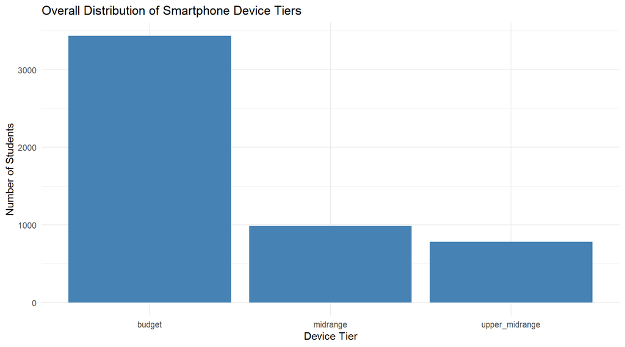

```r
ggplot(df, aes(x = device_range)) +
  geom_bar(fill = "steelblue") +
  theme_minimal() +
  labs(
    title = "Overall Distribution of Smartphone Device Tiers",
    x = "Device Tier",
    y = "Number of Students"
  )
```

## 3.2 Device tier distribution by region

```r
tier_region <- df %>%
  count(region, device_range) %>%
  group_by(region) %>%
  mutate(prop = n / sum(n)) %>%
  ungroup()

tier_region
```

```
## # A tibble: 41 × 4
##    region            device_range       n  prop
##    <fct>             <fct>          <int> <dbl>
##  1 addis ababa       budget           501 0.611
##  2 addis ababa       midrange         152 0.185
##  3 addis ababa       upper_midrange   167 0.204
##  4 afar              budget             1 0.5
##  5 afar              midrange           1 0.5
##  6 amhara            budget           253 0.617
##  7 amhara            midrange          87 0.212
##  8 amhara            upper_midrange    70 0.171
##  9 benishangul-gumuz budget             6 0.6
## 10 benishangul-gumuz midrange           3 0.3
## # ℹ 31 more rows
```

**Interpretation:** This table compares regions by the proportion of budget, midrange, and upper-midrange devices. Differences across regions can reflect unequal access to higher-quality devices.

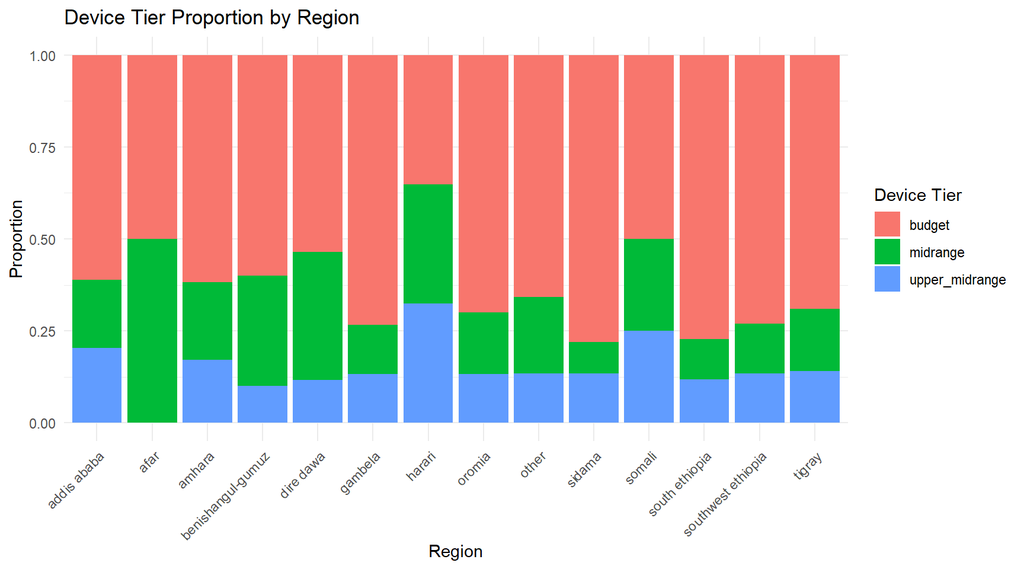

```r
ggplot(tier_region, aes(x = region, y = prop, fill = device_range)) +
  geom_col() +
  theme_minimal() +
  labs(
    title = "Device Tier Proportion by Region",
    x = "Region",
    y = "Proportion",
    fill = "Device Tier"
  ) +
  theme(axis.text.x = element_text(angle = 45, hjust = 1))
```

# 4 Confidence intervals for budget device share

I estimate 95% confidence intervals for the proportion of budget devices within each region.

```r
budget_ci <- df %>%
  filter(!is.na(region), !is.na(device_range)) %>%
  group_by(region) %>%
  summarise(
    n_region = n(),
    x_budget = sum(device_range == "budget"),
    .groups = "drop"
  ) %>%
  rowwise() %>%
  mutate(
    test = list(prop.test(x_budget, n_region)),
    p_hat = x_budget / n_region,
    conf_low = test$conf.int[1],
    conf_high = test$conf.int[2]
  ) %>%
  ungroup()

budget_ci
```

```
## # A tibble: 14 × 7
##    region             n_region x_budget test    p_hat conf_low conf_high
##    <fct>                 <int>    <int> <list>  <dbl>    <dbl>     <dbl>
##  1 addis ababa             820      501 <htest> 0.611   0.577      0.644
##  2 afar                      2        1 <htest> 0.5     0.0945     0.905
##  3 amhara                  410      253 <htest> 0.617   0.568      0.664
##  4 benishangul-gumuz        10        6 <htest> 0.6     0.274      0.863
##  5 dire dawa                43       23 <htest> 0.535   0.378      0.685
##  6 gambela                  15       11 <htest> 0.733   0.448      0.911
##  7 harari                   74       26 <htest> 0.351   0.246      0.472
##  8 oromia                  522      365 <htest> 0.699   0.658      0.738
##  9 other                  2559     1684 <htest> 0.658   0.639      0.676
## 10 sidama                  418      326 <htest> 0.780   0.736      0.818
## 11 somali                   20       10 <htest> 0.5     0.299      0.701
## 12 south ethiopia          202      156 <htest> 0.772   0.707      0.827
## 13 southwest ethiopia       37       27 <htest> 0.730   0.556      0.856
## 14 tigray                   71       49 <htest> 0.690   0.568      0.792
```

**Interpretation:** The confidence intervals show uncertainty around the estimated budget-device proportion in each region. Wider intervals usually occur in regions with smaller sample size.

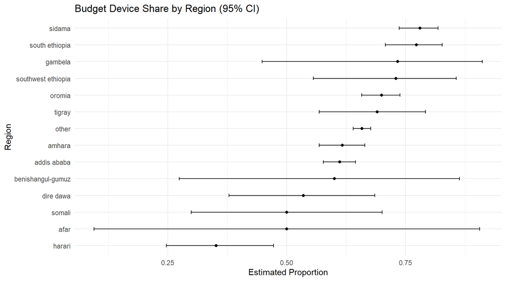

```r
ggplot(budget_ci, aes(x = reorder(region, p_hat), y = p_hat)) +
  geom_point() +
  geom_errorbar(aes(ymin = conf_low, ymax = conf_high), width = 0.2) +
  coord_flip() +
  theme_minimal() +
  labs(
    title = "Budget Device Share by Region (95% CI)",
    x = "Region",
    y = "Estimated Proportion"
  )
```

# 5 Chi-square test of association

I test whether device tier and region are statistically independent.

- **H0:** Device tier is independent of region.
- **H1:** Device tier distribution differs across regions.

```r
tab <- table(df$region, df$device_range)
tab
```

```
##
##                      budget midrange upper_midrange
##   addis ababa           501      152            167
##   afar                    1        1              0
##   amhara                253       87             70
##   benishangul-gumuz       6        3              1
##   dire dawa              23       15              5
##   gambela                11        2              2
##   harari                 26       24             24
##   oromia                365       88             69
##   other                1684      533            342
##   sidama                326       36             56
##   somali                 10        5              5
##   south ethiopia        156       22             24
##   southwest ethiopia     27        5              5
##   tigray                 49       12             10
```

```r
chi_test <- chisq.test(tab)
chi_test
```

```
##
##  Pearson's Chi-squared test
##
## data:  tab
## X-squared = 126.86, df = 26, p-value = 3.09e-15
```

```r
min_expected <- min(chi_test$expected)
min_expected
```

```
## [1] 0.299827
```

**Interpretation:** The p-value is extremely small, so I reject H0 and conclude that device tier distribution varies across regions.  
Because the minimum expected count is small, I also compute a Monte Carlo p-value as a robustness check.

```r
chi_mc <- chisq.test(tab, simulate.p.value = TRUE, B = 5000)
chi_mc
```

```
##
##  Pearson's Chi-squared test with simulated p-value (based on 5000
##  replicates)
##
## data:  tab
## X-squared = 126.86, df = NA, p-value = 2e-04
```

# 6 Logistic regression (Addis Ababa vs other regions)

To simplify the classification problem, I group the outcome into **Addis** versus **Other**.

```r
df <- df %>%
  mutate(
    region_group = ifelse(tolower(as.character(region)) == "addis ababa", "Addis", "Other"),
    region_group = as.factor(region_group)
  )

table(df$region_group)
```

```
##
## Addis Other
##   820  4383
```

```r
d_log <- df %>%
  dplyr::select(region_group, device_range, device_brand) %>%
  tidyr::drop_na()

log_model <- glm(region_group ~ device_range + device_brand,
                 data = d_log,
                 family = binomial)

summary(log_model)
```

```
##
## Call:
## glm(formula = region_group ~ device_range + device_brand, family = binomial,
##     data = d_log)
##
## Coefficients: (1 not defined because of singularities)
##                             Estimate Std. Error z value Pr(>|z|)
## (Intercept)                  1.70475    0.31382   5.432 5.57e-08 ***
## device_rangemidrange        11.86132  309.11995   0.038   0.9694
## device_rangeupper_midrange  11.43577  309.11998   0.037   0.9705
## device_brandblu            -15.27081  378.59300  -0.040   0.9678
## device_brandhisense         11.86132  378.59300   0.031   0.9750
## device_brandhuawei         -12.10745  309.11999  -0.039   0.9688
## device_brandinfinix          0.63498    0.35793   1.774   0.0761 .
## device_branditel             0.09806    0.41969   0.234   0.8153
## device_brandlenovo         -12.67477  309.12004  -0.041   0.9673
## device_brandmotorola       -12.64978  309.12035  -0.041   0.9674
## device_brandnokia            0.08701    1.12479   0.077   0.9383
## device_brandoppo           -12.22423  309.12019  -0.040   0.9685
## device_brandother           -0.18172    0.31917  -0.569   0.5691
## device_brandpixel          -12.87292  309.12221  -0.042   0.9668
## device_brandrealme         -10.90693  309.12041  -0.035   0.9719
## device_brandsafaricom       -0.09531    1.13951  -0.084   0.9333
## device_brandsamsung        -11.82167  309.11980  -0.038   0.9695
## device_brandtecno            0.59784    0.33698   1.774   0.0760 .
## device_brandvivo           -12.35276  309.12088  -0.040   0.9681
## device_brandwiko            11.86132  378.59300   0.031   0.9750
## device_brandxiaomi         -11.81877  309.12033  -0.038   0.9695
## device_brandzte                   NA         NA      NA       NA
## ---
## Signif. codes:  0 '***' 0.001 '**' 0.01 '*' 0.05 '.' 0.1 ' ' 1
##
## (Dispersion parameter for binomial family taken to be 1)
##
##     Null deviance: 4533.6  on 5202  degrees of freedom
## Residual deviance: 4439.7  on 5182  degrees of freedom
## AIC: 4481.7
##
## Number of Fisher Scoring iterations: 12
```

```r
AIC(log_model)
```

```
## [1] 4481.676
```

```r
BIC(log_model)
```

```
## [1] 4619.373
```

**Interpretation:** Logistic regression models the probability that a student is in **Addis** rather than **Other** given device tier and brand.  
AIC and BIC are used for comparing models (lower values indicate a better trade-off between fit and complexity).

# 7 Multinomial logistic regression (predicting region)

I fit a multinomial regression model to predict **region** using device tier and brand.

```r
d_multi <- df %>%
  dplyr::select(region, device_range, device_brand) %>%
  tidyr::drop_na()

multi_model <- nnet::multinom(region ~ device_range + device_brand,
                              data = d_multi,
                              trace = FALSE)

summary(multi_model)
```

```
## Call:
## nnet::multinom(formula = region ~ device_range + device_brand,
##     data = d_multi, trace = FALSE)
##
## Coefficients:
##                    (Intercept) device_rangemidrange device_rangeupper_midrange
## afar               -12.3683690             3.338667                  -7.459434
## amhara              -0.4976670             3.690473                   3.345173
## benishangul-gumuz   -6.1548832            -2.423942                  -3.600929
## dire dawa           -4.4218928             7.744830                   6.416884
## gambela             -6.6098005            -2.333765                  -2.422598
## harari              -6.4991744            -1.083061                  -1.202024
## oromia              -1.9421483             5.140121                   4.762708
## other                0.4480562            -4.983978                  -5.575629
## sidama              -2.6683825            -1.980390                  -1.346071
## somali              -6.8421549            -2.346877                  -2.432572
## south ethiopia      -3.1953656            -2.047719                  -2.047446
## southwest ethiopia  -5.3540935            -1.671104                  -1.831215
## tigray              -4.8334561            -3.679820                  -3.945409
##                    device_brandblu device_brandhisense device_brandhuawei
## afar                    -0.0237412         -0.02140602          -3.030143
## amhara                  -8.0272246         -1.30612872          -4.796794
## benishangul-gumuz       -2.2079305         -0.06421389          -2.758820
## dire dawa               -3.9796799         -0.10907620         -12.465831
## gambela                 -1.6222065         -0.06412886          -1.976023
## harari                  -1.2553105         -0.07781636          -2.975389
## oromia                  -6.7171939         -0.91913343          -3.907914
## other                   -9.3860837          7.80074984           5.405562
## sidama                  -6.5339621         -0.92000403           4.545949
## somali                  -1.2069173         -0.04967575          -2.185273
## south ethiopia          -5.8868394         -0.59618717           4.070866
## southwest ethiopia      -3.3742096         -0.16637970          -3.965356
## tigray                  -4.0192390         -0.20270959          -2.706039
##                    device_brandinfinix device_branditel device_brandlenovo
## afar                        -4.3814389       -1.1313260          -1.027982
## amhara                       0.5449397        0.2628902          -3.912360
## benishangul-gumuz            2.5267699        3.4296012          -1.875304
## dire dawa                    0.8043799       -5.7716500         -12.657445
## gambela                      4.3421992       -3.9870214          -1.985652
## harari                       2.8838990        5.1579765          -2.997200
```

[output cut: 179 more lines]

```
## amhara                   10.501938
## benishangul-gumuz        51.889151
## dire dawa                41.528085
## gambela                  47.137129
## harari                   37.636216
## oromia                   21.334741
## other                     9.816280
## sidama                   13.541910
## somali                   46.358584
## south ethiopia            8.432777
## southwest ethiopia        9.832030
## tigray                    9.356665
##
## Residual Deviance: 16623.66
## AIC: 17169.66
```

```r
AIC(multi_model)
```

```
## [1] 17169.66
```

```r
BIC(multi_model)
```

```
## [1] 18959.72
```

**Interpretation:** Multinomial regression extends logistic regression to multiple region categories. It helps evaluate whether device characteristics contain useful information for predicting geography.

# 8 LDA and QDA classification (Addis vs other)

I apply LDA and QDA to classify **Addis vs Other** using a compact numeric representation of device tier.

## 8.1 Train/test split

```r
set.seed(123)

d_cls <- df %>%
  dplyr::select(region_group, device_range) %>%
  tidyr::drop_na() %>%
  mutate(
    region_group = droplevels(as.factor(region_group)),
    device_range = droplevels(as.factor(device_range))
  )

train_index <- caret::createDataPartition(d_cls$region_group, p = 0.8, list = FALSE)
train <- d_cls[train_index, ]
test  <- d_cls[-train_index, ]

train_num <- train %>%
  mutate(device_range_num = as.numeric(device_range)) %>%
  dplyr::select(region_group, device_range_num)

test_num <- test %>%
  mutate(device_range_num = as.numeric(device_range)) %>%
  dplyr::select(region_group, device_range_num)

table(train_num$region_group)
```

```
##
## Addis Other
##   656  3507
```

```r
table(test_num$region_group)
```

```
##
## Addis Other
##   164   876
```

## 8.2 LDA

```r
lda_out <- tryCatch({
  lda_model <- MASS::lda(region_group ~ device_range_num, data = train_num)
  lda_pred <- predict(lda_model, newdata = test_num)$class
  caret::confusionMatrix(lda_pred, test_num$region_group)
}, error = function(e) {
  cat("LDA could not be fitted: ", e$message, "\n")
  NULL
})

lda_out
```

```
## Confusion Matrix and Statistics
##
##           Reference
## Prediction Addis Other
##      Addis     0     0
##      Other   164   876
##
##                Accuracy : 0.8423
##                  95% CI : (0.8187, 0.8639)
##     No Information Rate : 0.8423
##     P-Value [Acc > NIR] : 0.5208
##
##                   Kappa : 0
##
##  Mcnemar's Test P-Value : <2e-16
##
##             Sensitivity : 0.0000
##             Specificity : 1.0000
##          Pos Pred Value :    NaN
##          Neg Pred Value : 0.8423
##              Prevalence : 0.1577
##          Detection Rate : 0.0000
##    Detection Prevalence : 0.0000
##       Balanced Accuracy : 0.5000
##
##        'Positive' Class : Addis
##
```

## 8.3 QDA

```r
qda_out <- tryCatch({
  qda_model <- MASS::qda(region_group ~ device_range_num, data = train_num)
  qda_pred <- predict(qda_model, newdata = test_num)$class
  caret::confusionMatrix(qda_pred, test_num$region_group)
}, error = function(e) {
  cat("QDA could not be fitted: ", e$message, "\n")
  NULL
})

qda_out
```

```
## Confusion Matrix and Statistics
##
##           Reference
## Prediction Addis Other
##      Addis     0     0
##      Other   164   876
##
##                Accuracy : 0.8423
##                  95% CI : (0.8187, 0.8639)
##     No Information Rate : 0.8423
##     P-Value [Acc > NIR] : 0.5208
##
##                   Kappa : 0
##
##  Mcnemar's Test P-Value : <2e-16
##
##             Sensitivity : 0.0000
##             Specificity : 1.0000
##          Pos Pred Value :    NaN
##          Neg Pred Value : 0.8423
##              Prevalence : 0.1577
##          Detection Rate : 0.0000
##    Detection Prevalence : 0.0000
##       Balanced Accuracy : 0.5000
##
##        'Positive' Class : Addis
##
```

**Interpretation:** The confusion matrices summarize classification performance on the test set. Accuracy measures overall correctness, while sensitivity/specificity show class-wise performance.

# 9 Cross-validation (5-fold)

I estimate classification performance stability using 5-fold cross-validation.

```r
set.seed(123)

control <- trainControl(method = "cv", number = 5)

cv_lda <- caret::train(
  region_group ~ device_range,
  data = d_cls,
  method = "lda",
  trControl = control
)

cv_lda
```

```
## Linear Discriminant Analysis
##
## 5203 samples
##    1 predictor
##    2 classes: 'Addis', 'Other'
##
## No pre-processing
## Resampling: Cross-Validated (5 fold)
## Summary of sample sizes: 4162, 4162, 4162, 4163, 4163
## Resampling results:
##
##   Accuracy   Kappa
##   0.8423986  0
```

**Interpretation:** Cross-validation evaluates the model on multiple splits of the data. This gives a more reliable estimate of performance than using a single train/test split.

# 10 Conclusion

In this analysis, I studied digital access patterns among Ethiopian Grade 12 students using smartphone and regional data collected from my Star Exams application.

I found clear regional differences in device tier distribution, supported by confidence intervals and a chi-square test of association. I then evaluated how well device characteristics predict region using logistic regression, multinomial regression, and classification methods (LDA/QDA). Finally, I used cross-validation to assess classification stability.

Overall, the results provide evidence that smartphone access differs by region, which is consistent with regional disparities in digital learning readiness.